# Final Project Preliminary EDA

## Guiding Question (i.e., Research Question):

How do different aspects of determining how developed a country is (such as birth rate, population, death rate, etc.) manifest themselves in the spread of COVID-19. Essentially, how does COVID-19 show different levels of impact on different countries?

## Data Source Exploration

```r
COVID <- read.csv(\/Users/joeypevner/Final-Project/total-covid-cases-deaths-per-million.csv\) %>%
  rename(c(\country\ = \total.covid.cases.deaths.per.million\) ) %>%
  rename(c(\Code\ = \X\) ) %>%
  rename(c(\Date\ = \X.1\) ) %>%
  rename(c(\DeathsPerMillion\ = \X.2\)) %>%
  rename(c(\CasesPerMillion\ = \X.3\)) %>%
  filter(row_number() > 1) %>%
  subset(select = c(1,2,3,4,5)) %>%
  mutate( country = as.character(country) ) %>%
  mutate( Code = as.character(Code) ) %>%
  mutate(Date = mdy(Date)) %>%
  mutate(DeathsPerMillion = as.integer(DeathsPerMillion) - 1) %>%
  mutate(CasesPerMillion = as.integer(CasesPerMillion) - 1)

COVID
```

```r
NA
```

| country | Code | Date | DeathsPerMillion | CasesPerMillion |
| --- | --- | --- | --- | --- |
| Afghanistan | AFG | 2019-12-31 | 0 | 0 |
| Afghanistan | AFG | 2020-01-01 | 0 | 0 |
| Afghanistan | AFG | 2020-01-02 | 0 | 0 |
| Afghanistan | AFG | 2020-01-03 | 0 | 0 |
| Afghanistan | AFG | 2020-01-04 | 0 | 0 |
| Afghanistan | AFG | 2020-01-05 | 0 | 0 |
| Afghanistan | AFG | 2020-01-06 | 0 | 0 |
| Afghanistan | AFG | 2020-01-07 | 0 | 0 |
| Afghanistan | AFG | 2020-01-08 | 0 | 0 |
| Afghanistan | AFG | 2020-01-09 | 0 | 0 |

[output cut: 990 more lines]

```r
COVID%>%
  nrow()
```

```
[1] 9486
```

From this dataset, we will most likely be utilizing all of the variables which include: entity (country), code (country code), date (currently not in m/d/y format), total confirmed deaths per million, and total confirmed cases per million.

```r
COVID %>%
  names()
```

```
[1] \country\          \Code\             \Date\             \DeathsPerMillion\ \CasesPerMillion\
```

2. Dataset 2 - CountryData This dataset was accessed through the DataComputing Package. This data is collected and maintained by the CIA factbook. It was collected so that there is some type of database that contains various “geographic, demographic, and economic data” for each country.  
   Each case in this dataset represents an individual country, and there are 256 countries displayed in the dataset in total.

```r
CountryData
```

| country | area | pop | growth | birth | death | migr | maternal | infant | life | fert | health | HIVrate | HIVpeople | HIVdeath | obesity | underweight | educ | unemploymentYouth | GDP | GDPgrowth | GDPcapita | saving | indProd | labor | unemployment | family | tax | budget | debt | … |
| --- | --- | --- | --- | --- | --- | --- | --- | --- | --- | --- | --- | --- | --- | --- | --- | --- | --- | --- | --- | --- | --- | --- | --- | --- | --- | --- | --- | --- | --- | --- |
| Afghanistan | 652230 | 31822848 | 2.29 | 38.84 | 14.12 | -1.83 | 460 | 117.23 | 50.49 | 5.43 | 9.6 | 0.10 | 4300 | 300 | 2.2 | 32.9 | NA | NA | 4.530e+10 | 3.1 | 1100 | NA | NA | 7512000 | 35.0 | NA | 11.3 | -8.7 | NA | … |
| Akrotiri | 123 | 15700 | NA | NA | NA | NA | NA | NA | NA | NA | NA | NA | NA | NA | NA | NA | NA | NA | NA | NA | NA | NA | NA | NA | NA | NA | NA | NA | NA | … |
| Albania | 28748 | 3020209 | 0.30 | 12.73 | 6.47 | -3.31 | 27 | 13.19 | 77.96 | 1.50 | 6.3 | NA | NA | NA | 21.3 | 6.3 | 3.3 | 22.5 | 2.834e+10 | 0.7 | 10700 | 14.1 | 3.1 | 1098000 | 16.9 | 34.5 | 24.0 | -6.1 | 70.5 | … |
| Algeria | 2381741 | 38813722 | 1.88 | 23.99 | 4.31 | -0.93 | 97 | 21.76 | 76.39 | 2.78 | 3.9 | 0.10 | 18000 | 1000 | 16.0 | 3.7 | 4.3 | 28.4 | 2.847e+11 | 3.1 | 7500 | 45.5 | 2.5 | 11150000 | 10.3 | 35.3 | 37.3 | -2.3 | 13.2 | … |
| American Samoa | 199 | 54517 | -0.35 | 22.87 | 4.68 | -21.64 | NA | 8.92 | 74.91 | 2.98 | NA | NA | NA | NA | 74.6 | NA | NA | NA | 5.753e+08 | 3.0 | 8000 | NA | NA | 17630 | 29.8 | NA | 33.6 | -6.1 | NA | … |
| Andorra | 468 | 85458 | 0.17 | 8.48 | 6.82 | 0.00 | NA | 3.69 | 82.65 | 1.38 | 7.2 | NA | NA | NA | 25.2 | NA | NA | NA | 3.163e+09 | -1.6 | 37200 | NA | NA | 36060 | 4.0 | NA | 21.4 | -0.3 | 41.1 | … |
| Angola | 1246700 | 19088106 | 2.78 | 38.97 | 11.67 | 0.47 | 450 | 79.99 | 55.29 | 5.43 | 3.5 | 2.30 | 248800 | 12600 | 6.4 | 15.6 | 3.5 | NA | 1.318e+11 | 5.6 | 6300 | 19.1 | 5.5 | 9018000 | NA | NA | 42.5 | 3.4 | 14.7 | … |
| Anguilla | 91 | 16086 | 2.06 | 12.68 | 4.54 | 12.43 | NA | 3.40 | 81.20 | 1.75 | NA | NA | NA | NA | NA | NA | 2.8 | NA | 1.754e+08 | -8.5 | 12200 | NA | 2.0 | 6049 | 8.0 | NA | 39.6 | -5.0 | 20.0 | … |
| Antarctica | NA | NA | NA | NA | NA | NA | NA | NA | NA | NA | NA | NA | NA | NA | NA | NA | NA | NA | NA | NA | NA | NA | NA | NA | NA | NA | NA | NA | NA | … |
| Antigua and Barbuda | 443 | 91295 | 1.25 | 15.94 | 5.70 | 2.23 | NA | 13.29 | 76.12 | 2.03 | 5.9 | NA | NA | NA | 25.6 | NA | 2.4 | 19.9 | 1.610e+09 | 1.7 | 18400 | 18.0 | 1.0 | 30000 | 11.0 | NA | 19.6 | -0.8 | 89.0 | … |

[output cut: 246 more lines]

```r
CountryData %>%
  nrow()
```

```
[1] 256
```

From this dataset, we will be utilizing many of the variables that relate to the classifications of socio-economic development. For example, we will definitely have use for “pop” (the number of people), “growth” (the growth rate per year), “birth” (birth rate per 1000 people), and death (death rate per 1000 people).

```r
CountryData %>%
  names()
```

```
 [1] \country\           \area\              \pop\               \growth\            \birth\             \death\             \migr\
 [8] \maternal\          \infant\            \life\              \fert\              \health\            \HIVrate\           \HIVpeople\
[15] \HIVdeath\          \obesity\           \underweight\       \educ\              \unemploymentYouth\ \GDP\               \GDPgrowth\
[22] \GDPcapita\         \saving\            \indProd\           \labor\             \unemployment\      \family\            \tax\
[29] \budget\            \debt\              \inflation\         \discount\          \lending\           \narrow\            \broad\
[36] \credit\            \shares\            \balance\           \exports\           \imports\           \gold\              \externalDebt\
[43] \homeStock\         \abroadStock\       \elecProd\          \elecCons\          \elecExp\           \elecImp\           \elecCap\
[50] \elecFossil\        \elecNuc\           \elecHydro\         \elecRenew\         \oilProd\           \oilExp\            \oilImp\
[57] \oilRes\            \petroProd\         \petroCons\         \petroExp\          \petroImp\          \gasProd\           \gasCons\
[64] \gasExp\            \gasImp\            \gasRes\            \mainlines\         \cell\              \netHosts\          \netUsers\
[71] \airports\          \railways\          \roadways\          \waterways\         \marine\            \military\
```

## Intuitive Exploration

```r
All <- left_join(COVID, CountryData)
```

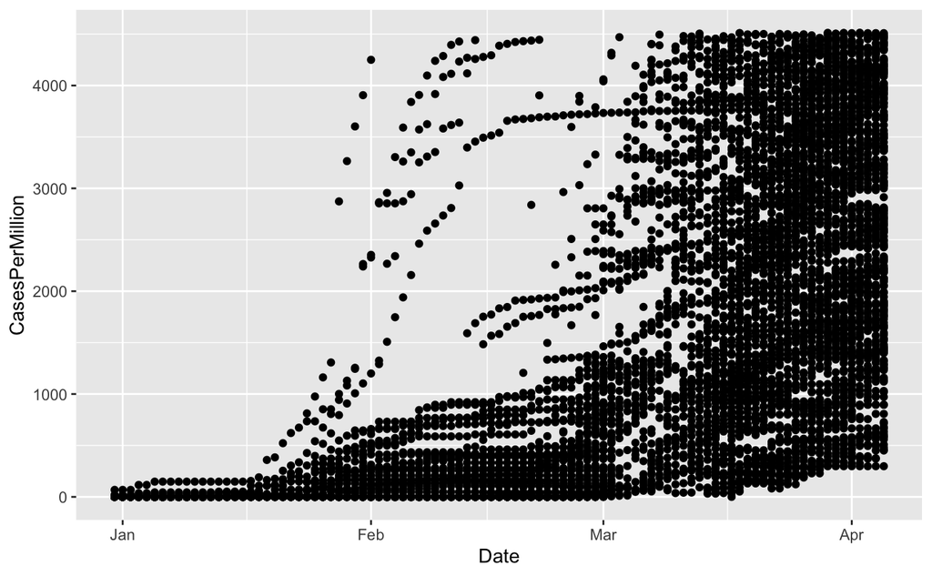

```r
ggplot(data = All,aes(x = Date, y = CasesPerMillion)) +
  geom_point()
```

```r
NA
NA
```

This graph shows that the total cases per million have increased significantly since January of 2020. While this is rather intuitive data, we will go into more indepth analysis about how different countries have progressed since January, and which are still experiencing a high growth rate in number of cases.

```r
February1 <-
  COVID %>%
  filter(Date == \2020-02-01\) %>%
  subset(select = c(1,4,5)) %>%
  rename(c(\DeathsPerMillionFeb1\ = \DeathsPerMillion\)) %>%
  rename(c(\CasesPerMillionFeb1\ = \CasesPerMillion\))

February29 <-
  COVID %>%
  filter(Date == \2020-02-29\) %>%
  subset(select = c(1,4,5)) %>%
  rename(c(\DeathsPerMillionFeb29\ = \DeathsPerMillion\)) %>%
  rename(c(\CasesPerMillionFeb29\ = \CasesPerMillion\))

FebGrow <-
  full_join(February1, February29, by = c(\country\)) %>%
  mutate(\CasesPerMillionFebGrowth\ = CasesPerMillionFeb29 - CasesPerMillionFeb1) %>%
  mutate(\DeathsPerMillionFebGrowth\ = DeathsPerMillionFeb29 - DeathsPerMillionFeb1)




March1 <-
  COVID %>%
  filter(Date == \2020-03-01\) %>%
  subset(select = c(1,4,5)) %>%
  rename(c(\DeathsPerMillionMarch1\ = \DeathsPerMillion\)) %>%
  rename(c(\CasesPerMillionMarch1\ = \CasesPerMillion\))

March31 <-
  COVID %>%
  filter(Date == \2020-03-31\) %>%
  subset(select = c(1,4,5)) %>%
  rename(c(\DeathsPerMillionMarch31\ = \DeathsPerMillion\)) %>%
  rename(c(\CasesPerMillionMarch31\ = \CasesPerMillion\))
```

```r
MarchGrow <-
  full_join(March1, March31, by = c(\country\)) %>%
  mutate(\CasesPerMillionMarchGrowth\ = CasesPerMillionMarch31 - CasesPerMillionMarch1) %>%
  mutate(\DeathsPerMillionMarchGrowth\ = DeathsPerMillionMarch31 - DeathsPerMillionMarch1)
```

```r
FebGrow <-
  FebGrow %>%
  subset(select = c(1, 6, 7))

MarchGrow <-
  MarchGrow %>%
  subset(select = c(1, 6, 7))

Growth <-
  All %>%
  left_join(FebGrow) %>%
  left_join(MarchGrow)
```

```r
Growth
```

```r
NA
```

| country | Code | Date | DeathsPerMillion | CasesPerMillion | area | pop | growth | birth | death | migr | maternal | infant | life | fert | health | HIVrate | HIVpeople | HIVdeath | obesity | underweight | educ | unemploymentYouth | GDP | GDPgrowth | GDPcapita | saving | indProd | labor | unemployment | … |
| --- | --- | --- | --- | --- | --- | --- | --- | --- | --- | --- | --- | --- | --- | --- | --- | --- | --- | --- | --- | --- | --- | --- | --- | --- | --- | --- | --- | --- | --- | --- |
| Afghanistan | AFG | 2019-12-31 | 0 | 0 | 652230 | 31822848 | 2.29 | 38.84 | 14.12 | -1.83 | 460 | 117.23 | 50.49 | 5.43 | 9.6 | 0.1 | 4300 | 300 | 2.2 | 32.9 | NA | NA | 4.530e+10 | 3.1 | 1100 | NA | NA | 7512000 | 35.0 | … |
| Afghanistan | AFG | 2020-01-01 | 0 | 0 | 652230 | 31822848 | 2.29 | 38.84 | 14.12 | -1.83 | 460 | 117.23 | 50.49 | 5.43 | 9.6 | 0.1 | 4300 | 300 | 2.2 | 32.9 | NA | NA | 4.530e+10 | 3.1 | 1100 | NA | NA | 7512000 | 35.0 | … |
| Afghanistan | AFG | 2020-01-02 | 0 | 0 | 652230 | 31822848 | 2.29 | 38.84 | 14.12 | -1.83 | 460 | 117.23 | 50.49 | 5.43 | 9.6 | 0.1 | 4300 | 300 | 2.2 | 32.9 | NA | NA | 4.530e+10 | 3.1 | 1100 | NA | NA | 7512000 | 35.0 | … |
| Afghanistan | AFG | 2020-01-03 | 0 | 0 | 652230 | 31822848 | 2.29 | 38.84 | 14.12 | -1.83 | 460 | 117.23 | 50.49 | 5.43 | 9.6 | 0.1 | 4300 | 300 | 2.2 | 32.9 | NA | NA | 4.530e+10 | 3.1 | 1100 | NA | NA | 7512000 | 35.0 | … |
| Afghanistan | AFG | 2020-01-04 | 0 | 0 | 652230 | 31822848 | 2.29 | 38.84 | 14.12 | -1.83 | 460 | 117.23 | 50.49 | 5.43 | 9.6 | 0.1 | 4300 | 300 | 2.2 | 32.9 | NA | NA | 4.530e+10 | 3.1 | 1100 | NA | NA | 7512000 | 35.0 | … |
| Afghanistan | AFG | 2020-01-05 | 0 | 0 | 652230 | 31822848 | 2.29 | 38.84 | 14.12 | -1.83 | 460 | 117.23 | 50.49 | 5.43 | 9.6 | 0.1 | 4300 | 300 | 2.2 | 32.9 | NA | NA | 4.530e+10 | 3.1 | 1100 | NA | NA | 7512000 | 35.0 | … |
| Afghanistan | AFG | 2020-01-06 | 0 | 0 | 652230 | 31822848 | 2.29 | 38.84 | 14.12 | -1.83 | 460 | 117.23 | 50.49 | 5.43 | 9.6 | 0.1 | 4300 | 300 | 2.2 | 32.9 | NA | NA | 4.530e+10 | 3.1 | 1100 | NA | NA | 7512000 | 35.0 | … |
| Afghanistan | AFG | 2020-01-07 | 0 | 0 | 652230 | 31822848 | 2.29 | 38.84 | 14.12 | -1.83 | 460 | 117.23 | 50.49 | 5.43 | 9.6 | 0.1 | 4300 | 300 | 2.2 | 32.9 | NA | NA | 4.530e+10 | 3.1 | 1100 | NA | NA | 7512000 | 35.0 | … |
| Afghanistan | AFG | 2020-01-08 | 0 | 0 | 652230 | 31822848 | 2.29 | 38.84 | 14.12 | -1.83 | 460 | 117.23 | 50.49 | 5.43 | 9.6 | 0.1 | 4300 | 300 | 2.2 | 32.9 | NA | NA | 4.530e+10 | 3.1 | 1100 | NA | NA | 7512000 | 35.0 | … |
| Afghanistan | AFG | 2020-01-09 | 0 | 0 | 652230 | 31822848 | 2.29 | 38.84 | 14.12 | -1.83 | 460 | 117.23 | 50.49 | 5.43 | 9.6 | 0.1 | 4300 | 300 | 2.2 | 32.9 | NA | NA | 4.530e+10 | 3.1 | 1100 | NA | NA | 7512000 | 35.0 | … |

[output cut: 990 more lines]

At the end of this table, you can see the addition of our columns called CasesPerMillionFebGrowth, DeathsPerMillionFebGrowth, CasesPerMillionMarchGrowth and DeathsPerMillionMarchGrowth. These show the change in the variables Deaths Per Million and Cases Per Million to show the change from the first day of the month to the last day of the month. This data can be further analyzed in many ways that will allow us to see the progression of the virus against different traits of a county.

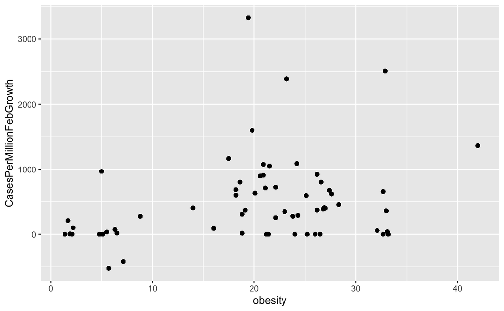

```r
ggplot(data = Growth, aes(x = obesity,y = CasesPerMillionFebGrowth)) +
  geom_point()
```

```r
NA
NA
```

In this graph, you can see that there is little to no direct relationship between the growth in cases in a country and the obesity in that country. This determines that these two will not be futher considered and explored in our analysis of the two datasets.

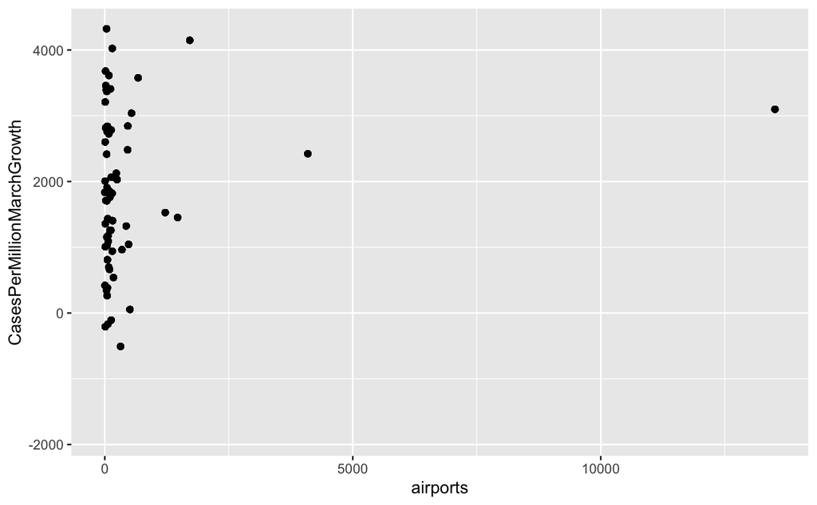

```r
ggplot(data=Growth, aes(x = airports,y = CasesPerMillionMarchGrowth)) +
  geom_point()
```

This graph would most likely need some manipulation to either remove or alter the effect of the outlier. However, this graph is meant to show the relationship between the number of airports in a country and their growth in COVID_19 cases throughout the month of March. This trend most likely would be very positive in the first two weeks of March (when travel was much less restricted) than in the last two weeks. This would be a trend that would be interesting to further investigate for our analysis.

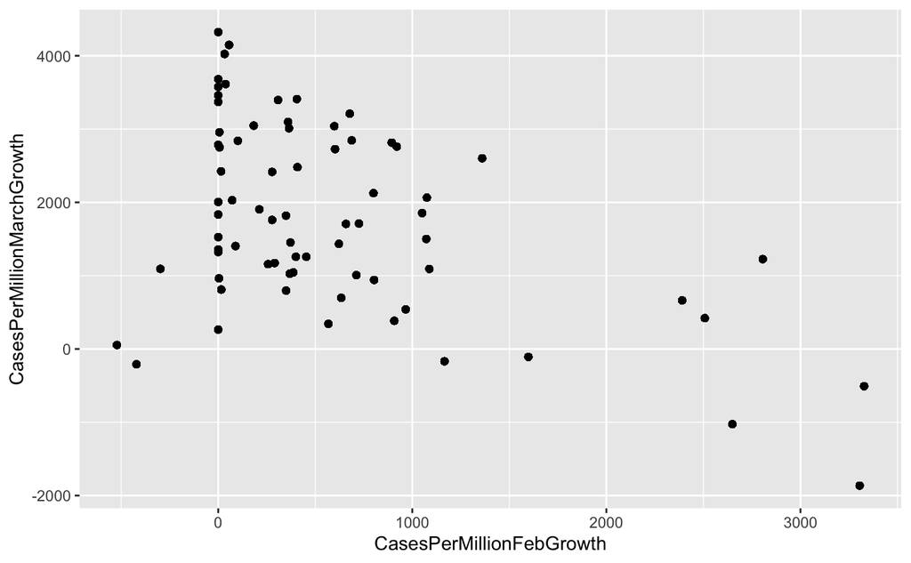

```r
ggplot(data=Growth,aes(x = CasesPerMillionFebGrowth,y = CasesPerMillionMarchGrowth)) +
  geom_point()
```

```r
NA
NA
```

This graph shows the negative trend between the CasesPerMillion Growths between February and March. That means that, for most countries, the higher the case per million growth in February, the lower the case per million growth in March. The opposite is also true, where the higher the case per million March growth, the lower the case per million February growth. This is most likely becuase those countries who had higher rates in February took more restrictive measures during this month, while those who had lower rates had not made those same adjustments yet.

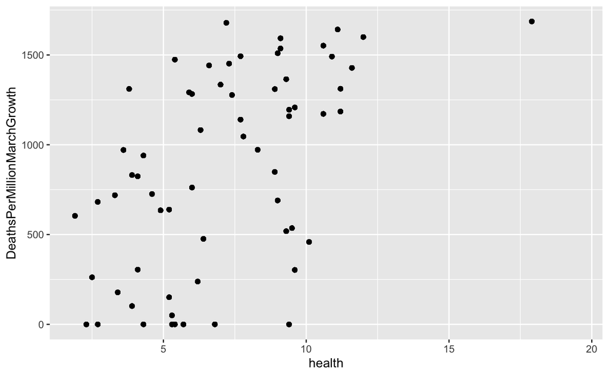

```r
ggplot(data=Growth, aes(x=health, y = DeathsPerMillionMarchGrowth)) +
  geom_point()
```

```r
NA
NA
```